# Tugas-Pertemuan-3

Rahma Annisa

2026-09-10

Deadline: Kamis, 10 September 2026 (23.59)

Data: Data deret waktu terdiri dari 72 observasi per jam. Data dibagi menjadi data Training (58 observasi) untuk pembentukan model, dan data Testing (14 observasi) untuk validasi peramalan.

variabel: Variabel Dependen (Y): AQI (Air Quality Index) Variabel Independen (X): pm25 (Konsentrasi partikulat PM2.5)

Metode: Metode regresi dengan peubah lag yang diterapkan adalah: 1.Model Koyck: Mengasumsikan penurunan pengaruh masa lalu secara eksponensial dan diringkas menggunakan lag pertama peubah dependen (Y(t-1)).  
2.Distributed Lag Model (DLM): Menghubungkan Y(t) dengan nilai X saat ini dan masa lalunya hingga batas lag tertentu (q). 3.Autoregressive Distributed Lag (ARDL): Memadukan pengaruh lag peubah X (p) dan lag peubah Y (q) secara bersamaan

```r
library(dLagM)
library(dynlm)
library(MLmetrics)
library(lmtest)
library(car)
```

Data

```r
#Dataset
data_air <- read.csv("C:/Users/hp/Downloads/NewDelhi_Air_quality.csv")

#variabel Y (AQI) dan X (pm25)
data_clean <- data.frame(
  Yt = data_air$AQI,
  Xt = data_air$pm25
)

#Membagi Data training 58 baris, testing 14 baris
train <- data_clean[1:58, ]
test  <- data_clean[59:72, ]

#mengonversi ke Time Series (ts)
train.ts <- ts(train)
test.ts  <- ts(test)
data.ts  <- ts(data_clean)

#Menampilkan data
head(train)
```

```
##     Yt       Xt
## 1 30.2 5.637410
## 2 28.2 4.618169
## 3 26.6 3.520902
## 4 25.0 2.225919
## 5 26.0 1.979471
## 6 26.0 1.792677
```

Model Koyck Model Koyck mengasumsikan bahwa bobot koefisien lag menurun secara eksponensial seiring bertambahnya jeda waktu

Permodelan

```r
model.koyck <- koyckDlm(x = train$Xt, y = train$Yt)
summary(model.koyck)
```

```
##
## Call:
## "Y ~ (Intercept) + Y.1 + X.t"
##
## Residuals:
##      Min       1Q   Median       3Q      Max
## -2.14443 -0.61319  0.03512  0.48195  2.18725
##
## Coefficients:
##             Estimate Std. Error t value Pr(>|t|)
## (Intercept)   4.0771     1.8299   2.228   0.0301 *
## Y.1           0.8897     0.0588  15.131   <2e-16 ***
## X.t          -0.5723     0.2854  -2.005   0.0500 *
## ---
## Signif. codes:  0 '***' 0.001 '**' 0.01 '*' 0.05 '.' 0.1 ' ' 1
##
## Residual standard error: 0.9279 on 54 degrees of freedom
## Multiple R-Squared: 0.8273,  Adjusted R-squared: 0.8209
## Wald test: 129.1 on 2 and 54 DF,  p-value: < 2.2e-16
##
## Diagnostic tests:
## NULL
##
##                             alpha       beta       phi
## Geometric coefficients:  36.94716 -0.5722988 0.8896496
```

Persamaan model Koyck yang diperoleh: AQI(t) = 4.0771 - 0.5723 PM2.5(t) + 0.8897 AQI(t-1)

1. Intercept: Estimasi = 4.0771, p-value = 0.0301 < 0.05. Tolak H0, intercept berpengaruh nyata.
2. PM2.5 (X.t): Estimasi = -0.5723, p-value = 0.0500 <= 0.05. Tolak H0, Xt berpengaruh nyata terhadap Yt.
3. Lag AQI (Y.1): Estimasi = 0.8897, p-value < 2e-16 < 0.05. Tolak H0, Yt-1 berpengaruh sangat nyata terhadap Yt.

Kebaikan Model 1. Adjusted R-squared = 0.8209: Model mampu menjelaskan 82.09% keragaman AQI. 2. Wald Test: p-value < 2.2e-16 < 0.05. Tolak H0, variabel bebas dan lag berpengaruh nyata.

Peramalan

```r
#tabel lag 1 sampai 10
dlm_aic <- finiteDLMauto(formula = Yt ~ Xt,
                         data = data.frame(train),
                         q.min = 1, q.max = 10,
                         model.type = "dlm",
                         error.type = "AIC",
                         trace = FALSE)
print(dlm_aic)
```

```
##    q - k    MASE      AIC      BIC    GMRAE   MBRAE R.Adj.Sq    Ljung-Box
## 10    10 1.72201 186.2653 210.5909 49688.22 0.71611  0.52879 1.423614e-08
```

```r
#q dengan AIC minimum
q_opt <- which.min(dlm_aic$AIC)
cat("Lag q optimum terpilih untuk DLM adalah:", q_opt, "\n")
```

```
## Lag q optimum terpilih untuk DLM adalah: 1
```

Regression with Distributed Lag (DLM) penentuan Lag q optimum dipilih berdasarkan kriteria nilai Akaike Information Criterion (AIC) terendah

```r
#Model DLM
model.dlm.opt <- dlm(x = train$Xt, y = train$Yt, q = q_opt)
summary(model.dlm.opt)
```

```
##
## Call:
## lm(formula = model.formula, data = design)
##
## Residuals:
##     Min      1Q  Median      3Q     Max
## -5.2450 -1.2419 -0.3730  0.9165  4.4062
##
## Coefficients:
##             Estimate Std. Error t value Pr(>|t|)
## (Intercept)   31.691      1.403  22.595  < 2e-16 ***
## x.t           -5.051      1.584  -3.188  0.00238 **
## x.1            2.783      1.126   2.471  0.01665 *
## ---
## Signif. codes:  0 '***' 0.001 '**' 0.01 '*' 0.05 '.' 0.1 ' ' 1
##
## Residual standard error: 2.018 on 54 degrees of freedom
## Multiple R-squared:  0.1831, Adjusted R-squared:  0.1528
## F-statistic:  6.05 on 2 and 54 DF,  p-value: 0.004256
##
## AIC and BIC values for the model:
##        AIC      BIC
## 1 246.7199 254.8921
```

Uji Autokorelasi H₀: Tidak terdapat autokorelasi pada sisaan H₁: Terdapat autokorelasi pada sisaan

Persamaan model: Yt = 31.691 - 5.051 Xt + 2.783 Xt-1

1. Intercept: Estimasi = 31.691, p-value < 2e-16 < 0.05. Tolak H0, intercept berpengaruh nyata.
2. PM2.5 saat ini (x.t): Estimasi = -5.051, p-value = 0.00238 < 0.05. Tolak H0, Xt berpengaruh nyata terhadap Yt.
3. Lag 1 PM2.5 (x.1): Estimasi = 2.783, p-value = 0.01665 < 0.05. Tolak H0, Xt-1 berpengaruh nyata terhadap Yt.

Kebaikan Model 1. Adjusted R-squared = 0.1528: Model mampu menjelaskan 15.28% keragaman AQI. 2. Uji F: p-value = 0.004256 < 0.05. Tolak H0, peubah Xt dan Xt-1 berpengaruh nyata secara simultan terhadap Yt.

```r
#Model dynlm menggunakan lag DLM optimum q optimum
model.dyn <- dynlm(Yt ~ L(Xt, 0:q_opt), data = train.ts)

#Uji Autokorelasi
dwtest(model.dyn)
```

```
##
##  Durbin-Watson test
##
## data:  model.dyn
## DW = 0.3953, p-value = 1.217e-15
## alternative hypothesis: true autocorrelation is greater than 0
```

```r
bgtest(model.dyn, order = 2)
```

```
##
##  Breusch-Godfrey test for serial correlation of order up to 2
##
## data:  model.dyn
## LM test = 36.276, df = 2, p-value = 1.327e-08
```

Pemodelan Awal ARDL Model ARDL menggabungkan pengaruh dari peubah independen masa lalu dan peubah dependen masa lalu.

```r
#Model ARDL dengan lag X = 1 dan lag Y = 1
model.ardl <- ardlDlm(formula = Yt ~ Xt, data = train, p = 1, q = 1)
summary(model.ardl)
```

```
##
## Time series regression with "ts" data:
## Start = 2, End = 58
##
## Call:
## dynlm(formula = as.formula(model.text), data = data)
##
## Residuals:
##      Min       1Q   Median       3Q      Max
## -2.14374 -0.61593  0.03152  0.47781  2.18777
##
## Coefficients:
##             Estimate Std. Error t value Pr(>|t|)
## (Intercept)  4.00535    2.07382   1.931   0.0588 .
## Xt.t        -0.52588    0.80265  -0.655   0.5152
## Xt.1        -0.03046    0.55965  -0.054   0.9568
## Yt.1         0.89112    0.06338  14.060   <2e-16 ***
## ---
## Signif. codes:  0 '***' 0.001 '**' 0.01 '*' 0.05 '.' 0.1 ' ' 1
##
## Residual standard error: 0.9366 on 53 degrees of freedom
## Multiple R-squared:  0.8273, Adjusted R-squared:  0.8175
## F-statistic: 84.63 on 3 and 53 DF,  p-value: < 2.2e-16
```

Penentuan Lag Optimum ARDL

```r
#lag optimum p dan q untuk ARDL
model.ardl.opt <- ardlBoundOrders(data = data.frame(train), ic = "AIC", formula = Yt ~ Xt)

#lag dengan nilai AIC terkecil
min_p <- c()
for(i in 1:length(model.ardl.opt$Stat.table)){
  min_p[i] <- min(model.ardl.opt$Stat.table[[i]], na.rm = TRUE)
}

q_opt_ardl <- which(min_p == min(min_p, na.rm = TRUE))[1]
p_opt_ardl <- which(model.ardl.opt$Stat.table[[q_opt_ardl]] == min(model.ardl.opt$Stat.table[[q_opt_ardl]], na.rm = TRUE))[1]

data.frame("Lag_Y_opt(q)" = q_opt_ardl,
           "Lag_X_opt(p)" = p_opt_ardl,
           "AIC_Terkecil" = model.ardl.opt$min.Stat)
```

```
##   Lag_Y_opt.q. Lag_X_opt.p. AIC_Terkecil
## 1           11           15     61.97934
```

Peramalan Model ARDL

```r
#Peramalan model ARDL data testing
fore.ardl <- forecast(model = model.ardl, x = test$Xt, h = nrow(test))
fore.ardl
```

```
## $forecasts
##  [1] 22.97840 22.82860 22.64511 22.45145 22.29209 22.21092 22.21013 22.25281
##  [9] 22.31471 22.37658 22.43590 22.47324 22.48616 22.51451
##
## $call
## forecast.ardlDlm(model = model.ardl, x = test$Xt, h = nrow(test))
##
## attr(,"class")
## [1] "forecast.ardlDlm" "dLagM"
```

```r
#MAPE data testing
mape.ardl <- MAPE(fore.ardl$forecasts, test$Yt)
cat("MAPE Model ARDL:", mape.ardl, "\n")
```

```
## MAPE Model ARDL: 0.1064417
```

Pendekatan dynlm & Pembentukan Model

```r
#Model dynlm ARDL optimum
model.dyn <- dynlm(Yt ~ L(Xt, 0:p_opt_ardl) + L(Yt, 1:q_opt_ardl), data = train.ts)
summary(model.dyn)
```

```
##
## Time series regression with "ts" data:
## Start = 16, End = 58
##
## Call:
## dynlm(formula = Yt ~ L(Xt, 0:p_opt_ardl) + L(Yt, 1:q_opt_ardl),
##     data = train.ts)
##
## Residuals:
##      Min       1Q   Median       3Q      Max
## -0.81229 -0.18134  0.00091  0.12950  0.97061
##
## Coefficients:
##                        Estimate Std. Error t value Pr(>|t|)
## (Intercept)           30.066533  15.947685   1.885   0.0789 .
## L(Xt, 0:p_opt_ardl)0  -6.141445   3.005541  -2.043   0.0590 .
## L(Xt, 0:p_opt_ardl)1   4.939832   7.671240   0.644   0.5293
## L(Xt, 0:p_opt_ardl)2   5.397631   8.747045   0.617   0.5464
## L(Xt, 0:p_opt_ardl)3   0.325293   9.111148   0.036   0.9720
## L(Xt, 0:p_opt_ardl)4  -3.890672   8.768602  -0.444   0.6636
## L(Xt, 0:p_opt_ardl)5   3.606153   8.572937   0.421   0.6800
## L(Xt, 0:p_opt_ardl)6  -0.953554   9.244986  -0.103   0.9192
## L(Xt, 0:p_opt_ardl)7  -6.713773   9.409528  -0.714   0.4865
## L(Xt, 0:p_opt_ardl)8  -1.600435   8.852723  -0.181   0.8590
## L(Xt, 0:p_opt_ardl)9   3.204958   8.041241   0.399   0.6958
## L(Xt, 0:p_opt_ardl)10 -1.855250   7.358452  -0.252   0.8044
## L(Xt, 0:p_opt_ardl)11 -2.513331   6.206677  -0.405   0.6912
## L(Xt, 0:p_opt_ardl)12  4.368256   4.201647   1.040   0.3150
## L(Xt, 0:p_opt_ardl)13 -1.614666   2.633300  -0.613   0.5489
## L(Xt, 0:p_opt_ardl)14 -1.926334   2.528903  -0.762   0.4580
## L(Xt, 0:p_opt_ardl)15  1.837046   1.414623   1.299   0.2137
## L(Yt, 1:q_opt_ardl)1   0.248799   0.246206   1.011   0.3283
## L(Yt, 1:q_opt_ardl)2   0.337209   0.276693   1.219   0.2418
## L(Yt, 1:q_opt_ardl)3   0.222851   0.254979   0.874   0.3959
## L(Yt, 1:q_opt_ardl)4  -0.006165   0.255883  -0.024   0.9811
## L(Yt, 1:q_opt_ardl)5   0.177835   0.255951   0.695   0.4978
## L(Yt, 1:q_opt_ardl)6  -0.337300   0.237644  -1.419   0.1762
## L(Yt, 1:q_opt_ardl)7  -0.061616   0.253548  -0.243   0.8113
## L(Yt, 1:q_opt_ardl)8   0.042998   0.242156   0.178   0.8614
## L(Yt, 1:q_opt_ardl)9  -0.170620   0.245856  -0.694   0.4983
## L(Yt, 1:q_opt_ardl)10 -0.232883   0.245047  -0.950   0.3570
## L(Yt, 1:q_opt_ardl)11 -0.063048   0.245363  -0.257   0.8007
## ---
## Signif. codes:  0 '***' 0.001 '**' 0.01 '*' 0.05 '.' 0.1 ' ' 1
##
## Residual standard error: 0.5341 on 15 degrees of freedom
## Multiple R-squared:  0.9793, Adjusted R-squared:  0.942
## F-statistic: 26.25 on 27 and 15 DF,  p-value: 1.903e-08
```

Uji Autokorelasi

```r
#Uji Autokorelasi Durbin-Watson dan Breusch-Godfrey
dwtest(model.dyn)
```

```
##
##  Durbin-Watson test
##
## data:  model.dyn
## DW = 2.1302, p-value = 0.2908
## alternative hypothesis: true autocorrelation is greater than 0
```

```r
bgtest(model.dyn, order = 2)
```

```
##
##  Breusch-Godfrey test for serial correlation of order up to 2
##
## data:  model.dyn
## LM test = 1.7045, df = 2, p-value = 0.4264
```

H0: Tidak terdapat autokorelasi pada sisaan

Uji Heteroskedastisitas

```r
#Uji Heteroskedastisitas(Breusch-Pagan)
bptest(model.dyn)
```

```
##
##  studentized Breusch-Pagan test
##
## data:  model.dyn
## BP = 25.475, df = 27, p-value = 0.5478
```

H0: Ragam sisaan homogen (homoskedastisitas)

Uji Normalitas Sisaan

```r
#Uji Normalitas Shapiro-Wilk
shapiro.test(residuals(model.dyn))
```

```
##
##  Shapiro-Wilk normality test
##
## data:  residuals(model.dyn)
## W = 0.95715, p-value = 0.109
```

H0: Sisaan berdistribusi normal

Ringkasan

```r
#Peramalan dan MAPE ketiga model
fore.koyck <- forecast(model = model.koyck, x = test$Xt, h = nrow(test))
mape.koyck <- MAPE(fore.koyck$forecasts, test$Yt)

fore.dlm.opt <- forecast(model = model.dlm.opt, x = test$Xt, h = nrow(test))
mape.dlm.opt <- MAPE(fore.dlm.opt$forecasts, test$Yt)

fore.ardl <- forecast(model = model.ardl, x = test$Xt, h = nrow(test))
mape.ardl <- MAPE(fore.ardl$forecasts, test$Yt)

#SSE dari sisaan
dev_koyck <- sum(residuals(model.koyck)^2)
```

[output not shown]

```r
dev_dlm   <- sum(residuals(model.dlm.opt)^2)
```

[output not shown]

```r
dev_ardl  <- sum(residuals(model.ardl)^2)
```

[output not shown]

```r
ringkasan_akurasi <- data.frame(
  Metode = c("Koyck",
             paste0("DLM Optimum (q = ", q_opt, ")"),
             paste0("ARDL Optimum (p = ", p_opt_ardl, ", q = ", q_opt_ardl, ")")),
  Deviance_SSE = c(dev_koyck, dev_dlm, dev_ardl),
  MAPE_Persen  = c(as.numeric(mape.koyck) * 100,
                   as.numeric(mape.dlm.opt) * 100,
                   as.numeric(mape.ardl) * 100)
)

knitr::kable(ringkasan_akurasi, digits = 4, caption = "Perbandingan Akurasi Model Peubah Lag")
```

Perbandingan Akurasi Model Peubah Lag

[output not shown]

Visualisasi Aktual vs Peramalan

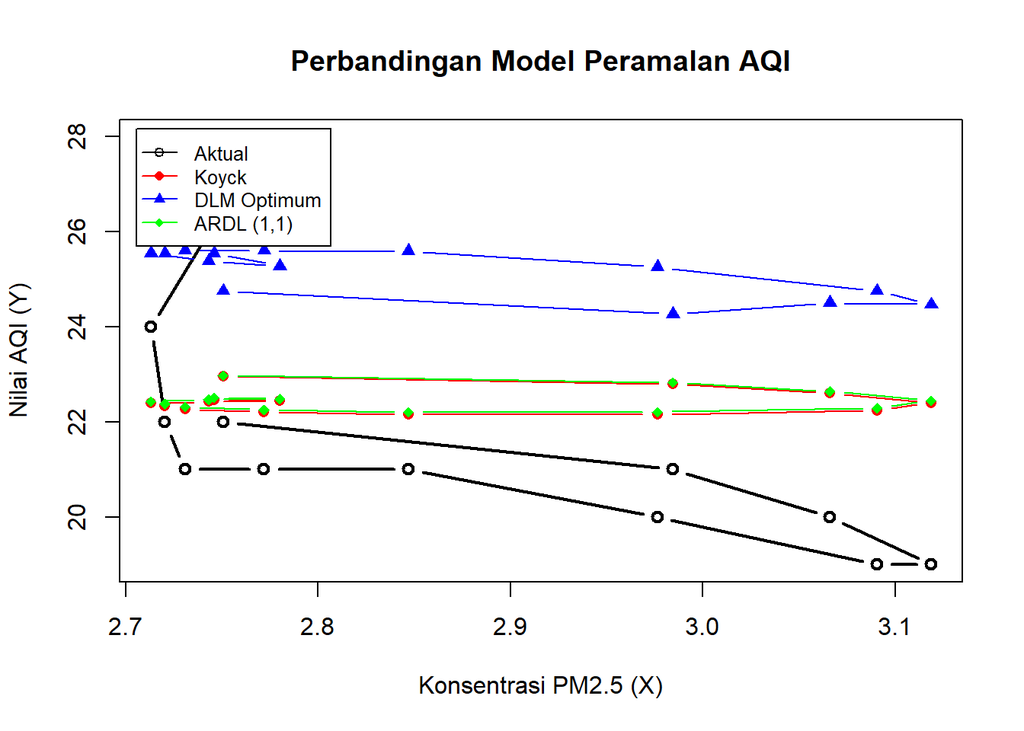

```r
par(mfrow=c(1,1))

rentang_y <- range(c(test$Yt, fore.koyck$forecasts, fore.dlm.opt$forecasts, fore.ardl$forecasts))

plot(test$Xt, test$Yt, type="b", col="black", ylim=rentang_y, lwd=2,
     ylab="Nilai AQI (Y)", xlab="Konsentrasi PM2.5 (X)", main="Perbandingan Model Peramalan AQI")

lines(test$Xt, fore.koyck$forecasts, col="red", type="b", pch=16)
lines(test$Xt, fore.dlm.opt$forecasts, col="blue", type="b", pch=17)
lines(test$Xt, fore.ardl$forecasts, col="green", type="b", pch=18)

legend("topleft", legend=c("Aktual", "Koyck", "DLM Optimum", "ARDL (1,1)"),
       col=c("black","red","blue","green"), lty=1, pch=c(1,16,17,18), cex=0.8, inset=0.02)
```